# R Notebook

Week 10 - Weekend Homework - Model Building

Investigate the avocado dataset, in particular, the AveragePrice of avocados.

Focus on either explanatory, or predictive model.

As part of MVP, to not just run the code and build the model, but also interpret results and write thinking and comments in the script.

```r
# reading in libraries

library(tidyverse)
library(modelr)
library(GGally)
library(janitor)
library(lubridate)
```

```r
# reading in data

avocado <- read_csv("data/avocado.csv")
```

```
* `` -> ...1
```

```r
avocado <- avocado %>%
  clean_names()

# cleaning the variable names
```

```r
# exploring the data

# 4046 - is total number of avocados with PLU 4046 sold
# 4225 - same
# 4770 - same

summary(avocado)
```

```
       x1             date            average_price    total_volume          x4046              x4225              x4770           total_bags         small_bags
 Min.   : 0.00   Min.   :2015-01-04   Min.   :0.440   Min.   :      85   Min.   :       0   Min.   :       0   Min.   :      0   Min.   :       0   Min.   :       0
 1st Qu.:10.00   1st Qu.:2015-10-25   1st Qu.:1.100   1st Qu.:   10839   1st Qu.:     854   1st Qu.:    3009   1st Qu.:      0   1st Qu.:    5089   1st Qu.:    2849
 Median :24.00   Median :2016-08-14   Median :1.370   Median :  107377   Median :    8645   Median :   29061   Median :    185   Median :   39744   Median :   26363
 Mean   :24.23   Mean   :2016-08-13   Mean   :1.406   Mean   :  850644   Mean   :  293008   Mean   :  295155   Mean   :  22840   Mean   :  239639   Mean   :  182195
 3rd Qu.:38.00   3rd Qu.:2017-06-04   3rd Qu.:1.660   3rd Qu.:  432962   3rd Qu.:  111020   3rd Qu.:  150207   3rd Qu.:   6243   3rd Qu.:  110783   3rd Qu.:   83338
 Max.   :52.00   Max.   :2018-03-25   Max.   :3.250   Max.   :62505647   Max.   :22743616   Max.   :20470573   Max.   :2546439   Max.   :19373134   Max.   :13384587
   large_bags       x_large_bags          type                year         region
 Min.   :      0   Min.   :     0.0   Length:18249       Min.   :2015   Length:18249
 1st Qu.:    127   1st Qu.:     0.0   Class :character   1st Qu.:2015   Class :character
 Median :   2648   Median :     0.0   Mode  :character   Median :2016   Mode  :character
 Mean   :  54338   Mean   :  3106.4                      Mean   :2016
 3rd Qu.:  22029   3rd Qu.:   132.5                      3rd Qu.:2017
 Max.   :5719097   Max.   :551693.7                      Max.   :2018
```

```r
# there doesn't appear to be missing values

avocado %>%
  filter(x_large_bags == 0.00)
```

| x1 | date | average_price | total_volume | x4046 | x4225 | x4770 | total_bags | small_bags | large_bags | x_large_bags | type | year | region |
| --- | --- | --- | --- | --- | --- | --- | --- | --- | --- | --- | --- | --- | --- |
| 0 | 2015-12-27 | 1.33 | 64236.62 | 1036.74 | 54454.85 | 48.16 | 8696.87 | 8603.62 | 93.25 | 0 | conventional | 2015 | Albany |
| 1 | 2015-12-20 | 1.35 | 54876.98 | 674.28 | 44638.81 | 58.33 | 9505.56 | 9408.07 | 97.49 | 0 | conventional | 2015 | Albany |
| 2 | 2015-12-13 | 0.93 | 118220.22 | 794.70 | 109149.67 | 130.50 | 8145.35 | 8042.21 | 103.14 | 0 | conventional | 2015 | Albany |
| 3 | 2015-12-06 | 1.08 | 78992.15 | 1132.00 | 71976.41 | 72.58 | 5811.16 | 5677.40 | 133.76 | 0 | conventional | 2015 | Albany |
| 4 | 2015-11-29 | 1.28 | 51039.60 | 941.48 | 43838.39 | 75.78 | 6183.95 | 5986.26 | 197.69 | 0 | conventional | 2015 | Albany |
| 5 | 2015-11-22 | 1.26 | 55979.78 | 1184.27 | 48067.99 | 43.61 | 6683.91 | 6556.47 | 127.44 | 0 | conventional | 2015 | Albany |
| 6 | 2015-11-15 | 0.99 | 83453.76 | 1368.92 | 73672.72 | 93.26 | 8318.86 | 8196.81 | 122.05 | 0 | conventional | 2015 | Albany |
| 7 | 2015-11-08 | 0.98 | 109428.33 | 703.75 | 101815.36 | 80.00 | 6829.22 | 6266.85 | 562.37 | 0 | conventional | 2015 | Albany |
| 8 | 2015-11-01 | 1.02 | 99811.42 | 1022.15 | 87315.57 | 85.34 | 11388.36 | 11104.53 | 283.83 | 0 | conventional | 2015 | Albany |
| 9 | 2015-10-25 | 1.07 | 74338.76 | 842.40 | 64757.44 | 113.00 | 8625.92 | 8061.47 | 564.45 | 0 | conventional | 2015 | Albany |

[output cut: 990 more lines]

```r
# there are 12048 of these obsverations - worth bearing in mind

avocado %>%
  distinct(region)
```

| region |
| --- |
| Albany |
| Atlanta |
| BaltimoreWashington |
| Boise |
| Boston |
| BuffaloRochester |
| California |
| Charlotte |
| Chicago |
| CincinnatiDayton |

[output cut: 44 more lines]

```r
# there are 54 distinct values in this category - worth bearing in mind

avocado %>%
  distinct(type)
```

| type |
| --- |
| conventional |
| organic |

```r
# this can be converted to column type "organic" and then TRUE/FALSE

# date won't be needed, but the month can be extracted from this.
```

```r
# changing the type column to is_organic, and restructuring the data to match.
# extracting the month from the date and dropping the date column
# renaming the number columns - from experience, having columns start with x can be problematic in analysis
# I have also come back and renamed these when beginning the model, as it is
# unable to accept the names of variables as numbers, so to make life easier
# as I'm renaming them anyways, I've renamed them with characters

clean_avocado <- avocado %>%
  mutate(month = month(date, label = FALSE, abbr = FALSE),
         is_organic = if_else(type == "organic", TRUE, FALSE)
         ) %>%
  select(-c("date", "type")) %>%
  rename("four_046" = x4046,
    "four_225" = x4225,
    "four_770" = x4770)
```

I will attempt to build an explanatory model.

Steps

Use ggpairs() to explore correlations (grouped, if need be) I will probably exclude region to begin with, as there are too many possibilities under this Choose my initial predictors Select a predictor, and build the first model Use summary() to explore the stats Use par(mfrow = c(2, 2)) and plot() to check the plots Check these for my first options and make my final selection for my first one Run ggpairs() again to select my second predictor, excluding the first predictor I added in Build the model Use par(mfrow = c(2, 2)) and plot() to check the plots Check these for my first options and make my final selection for my first one Use anova() to check for statistical significance / difference Repeat, until I have added 3 / 4

[output not shown]

[output cut: 155 more lines]

[figure not shown]

```r
clean_avocado %>%
  select(-region) %>%
  ggpairs()
```

It’s a bit hard to read from this graph / overview, but the following ones could be good indicators: volume 4046 4225 4770 total small large x_large month

Slimming it down a bit to look again, and be able to see better

[output not shown]

[output cut: 74 more lines]

[figure not shown]

```r
clean_avocado %>%
  select(-c("x1", "region", "year", "is_organic")) %>%
  ggpairs()
```

Now I can see that the follow indicators are good: total_volume four_046 (this has the highest, so this will be my first choice) four_225 four_770 total_bags small_bags large_bags

Month may be good, but it’s very in between.

x_large_bags is not good.

Getting a closer look at is_organic

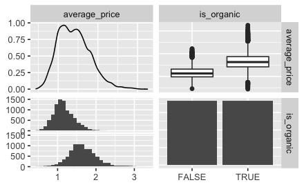

```r
clean_avocado %>%
  select(average_price, is_organic) %>%
  ggpairs()
```

There appears to be some variation in this graph, so this is also a good one to go for.

Time to build the first model.

```r
model_1_a <- lm(average_price ~ four_046, data = clean_avocado)
model_1_a
```

```
Call:
lm(formula = average_price ~ four_046, data = clean_avocado)

Coefficients:
(Intercept)     four_046
  1.425e+00   -6.631e-08
```

```r
summary(model_1_a)
```

```
Call:
lm(formula = average_price ~ four_046, data = clean_avocado)

Residuals:
     Min       1Q   Median       3Q      Max
-0.98539 -0.29842 -0.03531  0.25459  1.82475

Coefficients:
              Estimate Std. Error t value Pr(>|t|)
(Intercept)  1.425e+00  2.993e-03  476.29   <2e-16 ***
four_046    -6.631e-08  2.305e-09  -28.77   <2e-16 ***
---
Signif. codes:  0 ‘***’ 0.001 ‘**’ 0.01 ‘*’ 0.05 ‘.’ 0.1 ‘ ’ 1

Residual standard error: 0.3939 on 18247 degrees of freedom
Multiple R-squared:  0.0434,    Adjusted R-squared:  0.04334
F-statistic: 827.8 on 1 and 18247 DF,  p-value: < 2.2e-16
```

From these statistics, what can be inferred is that there is a good p-value (under 0.05) so the model is statistically significant, but it also only accounts for 4.3% of the variation, which is very low.

[figure not shown]

```r
par(mfrow = c(2, 2))
plot(model_1_a)
```

The diagnostic plots also aren’t very good - the QQ plot is in a straight line, but in the residuals vs fitted, there are two clear groups (which is also seen in the scale/location plot). Time to try a different variable.

I’ll go back and look at the total_volume; the above variable is quite specific, so it could very well be throwing the model off.

```r
model_1_b <- lm(average_price ~ total_volume, data = clean_avocado)
model_1_b
```

```
Call:
lm(formula = average_price ~ total_volume, data = clean_avocado)

Coefficients:
 (Intercept)  total_volume
   1.425e+00    -2.247e-08
```

Checking the summary of the 2nd model

```r
summary(model_1_b)
```

```
Call:
lm(formula = average_price ~ total_volume, data = clean_avocado)

Residuals:
     Min       1Q   Median       3Q      Max
-0.98366 -0.29994 -0.03319  0.25498  1.82528

Coefficients:
               Estimate Std. Error t value Pr(>|t|)
(Intercept)   1.425e+00  3.012e-03  473.07   <2e-16 ***
total_volume -2.247e-08  8.470e-10  -26.54   <2e-16 ***
---
Signif. codes:  0 ‘***’ 0.001 ‘**’ 0.01 ‘*’ 0.05 ‘.’ 0.1 ‘ ’ 1

Residual standard error: 0.3951 on 18247 degrees of freedom
Multiple R-squared:  0.03715,   Adjusted R-squared:  0.0371
F-statistic: 704.1 on 1 and 18247 DF,  p-value: < 2.2e-16
```

This model is also statistically significant, but account for even less than the previous, only 3.7% here.

Checking the diagnostic plots

[figure not shown]

```r
par(mfrow = c(2, 2))
plot(model_1_b)
```

This is no better. There still appears to be two distinct groups.

I will check the is_organic variable.

```r
model_1_c <- lm(average_price ~ is_organic, data = clean_avocado)
model_1_c
```

```
Call:
lm(formula = average_price ~ is_organic, data = clean_avocado)

Coefficients:
   (Intercept)  is_organicTRUE
         1.158           0.496
```

```r
summary(model_1_c)
```

```
Call:
lm(formula = average_price ~ is_organic, data = clean_avocado)

Residuals:
     Min       1Q   Median       3Q      Max
-1.21400 -0.20400 -0.02804  0.18600  1.59600

Coefficients:
               Estimate Std. Error t value Pr(>|t|)
(Intercept)    1.158040   0.003321   348.7   <2e-16 ***
is_organicTRUE 0.495959   0.004697   105.6   <2e-16 ***
---
Signif. codes:  0 ‘***’ 0.001 ‘**’ 0.01 ‘*’ 0.05 ‘.’ 0.1 ‘ ’ 1

Residual standard error: 0.3173 on 18247 degrees of freedom
Multiple R-squared:  0.3793,    Adjusted R-squared:  0.3792
F-statistic: 1.115e+04 on 1 and 18247 DF,  p-value: < 2.2e-16
```

This is the best variation I have uncovered so far, accounting for 37.9% of the variation, and the model is also statistically significant.

I will proceed to check the diagnostic plots.

[figure not shown]

```r
par(mfrow = c(2, 2))
plot(model_1_b)
```

As this is the best accounting for variation I have found so far, I will proceed with this model.

I will now progress with adding the second variable, i.e. building the second part onto the model. To do so, I will begin with exploring the correlations in ggpairs again (and in this, removing is_organic, which has already been used, and region, which has too many)

[output not shown]

[output cut: 95 more lines]

[figure not shown]

```r
clean_avocado %>%
  select(-c("x1", "region", "is_organic")) %>%
  ggpairs()
```

It’s a similar story, the following look good to explore: total_volume four_046 four_225 four_770 total_bags small_bags large_bags x_large_bags

In this case, I will begin with total_volume and four_046

```r
model_2_a <- lm(average_price ~ is_organic + total_volume, data = clean_avocado)
model_2_a
```

```
Call:
lm(formula = average_price ~ is_organic + total_volume, data = clean_avocado)

Coefficients:
   (Intercept)  is_organicTRUE    total_volume
     1.168e+00       4.861e-01      -6.115e-09
```

Checking the summary and diagnostic plot

```r
summary(model_2_a)
```

```
Call:
lm(formula = average_price ~ is_organic + total_volume, data = clean_avocado)

Residuals:
     Min       1Q   Median       3Q      Max
-1.21390 -0.20314 -0.02548  0.18575  1.59581

Coefficients:
                 Estimate Std. Error t value Pr(>|t|)
(Intercept)     1.168e+00  3.509e-03 332.878   <2e-16 ***
is_organicTRUE  4.861e-01  4.819e-03 100.872   <2e-16 ***
total_volume   -6.115e-09  6.978e-10  -8.763   <2e-16 ***
---
Signif. codes:  0 ‘***’ 0.001 ‘**’ 0.01 ‘*’ 0.05 ‘.’ 0.1 ‘ ’ 1

Residual standard error: 0.3166 on 18246 degrees of freedom
Multiple R-squared:  0.3819,    Adjusted R-squared:  0.3818
F-statistic:  5636 on 2 and 18246 DF,  p-value: < 2.2e-16
```

The model is still statisticall significant, but the variation covered has only gone up incrementally from the first model.

[figure not shown]

```r
par(mfrow = c(2, 2))
plot(model_2_a)
```

Looking at the diagnostic plots, there are now 3 distinct groups, and it is more evident that the model struggles as the values get higher (can be seen in residuals v fitted). The QQ plot still doesn’t look too bad though.

I will now look at the four_046

```r
model_2_b <- lm(average_price ~ is_organic + four_046, data = clean_avocado)
model_2_b
```

```
Call:
lm(formula = average_price ~ is_organic + four_046, data = clean_avocado)

Coefficients:
   (Intercept)  is_organicTRUE        four_046
     1.171e+00       4.827e-01      -2.323e-08
```

Looking at the summary stats for this plot

```r
summary(model_2_b)
```

```
Call:
lm(formula = average_price ~ is_organic + four_046, data = clean_avocado)

Residuals:
     Min       1Q   Median       3Q      Max
-1.21416 -0.20029 -0.02736  0.18591  1.59589

Coefficients:
                 Estimate Std. Error t value Pr(>|t|)
(Intercept)     1.171e+00  3.485e-03  336.13   <2e-16 ***
is_organicTRUE  4.827e-01  4.802e-03  100.52   <2e-16 ***
four_046       -2.323e-08  1.898e-09  -12.24   <2e-16 ***
---
Signif. codes:  0 ‘***’ 0.001 ‘**’ 0.01 ‘*’ 0.05 ‘.’ 0.1 ‘ ’ 1

Residual standard error: 0.316 on 18246 degrees of freedom
Multiple R-squared:  0.3843,    Adjusted R-squared:  0.3843
F-statistic:  5695 on 2 and 18246 DF,  p-value: < 2.2e-16
```

This is marginally better; 38.43 vs 38.19.

I will check the diagnostic plots

[figure not shown]

```r
par(mfrow = c(2, 2))
plot(model_2_b)
```

This is the same story as total_volume.

I will check month to see if this has any impact on the performance of the model, as it seems that this model does not response well to continuous variables.

```r
model_2_c <- lm(average_price ~ is_organic + month, data = clean_avocado)
model_2_c
```

```
Call:
lm(formula = average_price ~ is_organic + month, data = clean_avocado)

Coefficients:
   (Intercept)  is_organicTRUE           month
       1.04369         0.49597         0.01851
```

Checking the summary statistics

```r
summary(model_2_c)
```

```
Call:
lm(formula = average_price ~ is_organic + month, data = clean_avocado)

Residuals:
     Min       1Q   Median       3Q      Max
-1.15519 -0.20328 -0.02326  0.18780  1.55630

Coefficients:
                Estimate Std. Error t value Pr(>|t|)
(Intercept)    1.0436897  0.0051671  201.99   <2e-16 ***
is_organicTRUE 0.4959701  0.0045963  107.91   <2e-16 ***
month          0.0185107  0.0006503   28.46   <2e-16 ***
---
Signif. codes:  0 ‘***’ 0.001 ‘**’ 0.01 ‘*’ 0.05 ‘.’ 0.1 ‘ ’ 1

Residual standard error: 0.3105 on 18246 degrees of freedom
Multiple R-squared:  0.4057,    Adjusted R-squared:  0.4056
F-statistic:  6227 on 2 and 18246 DF,  p-value: < 2.2e-16
```

Surprisingly, this does increase the r-sq value somewhat, and it also remains statistically significant.

I will now check the diagnostic plots.

[figure not shown]

```r
par(mfrow = c(2, 2))
plot(model_2_c)
```

There is good, and bad news in this plot. There are still two distinct groups in the model, however the spread across the y axis in the residual v fitted has resolved and they are better distributed. The downside is, the residuals v leverage plot is not looking as good.

Nonetheless, I will proceed with these two variables. Prior to doing so, I will check them against the single variable, using anova.

```r
anova(model_1_c, model_2_c)
```

```
Analysis of Variance Table

Model 1: average_price ~ is_organic
Model 2: average_price ~ is_organic + month
  Res.Df    RSS Df Sum of Sq      F    Pr(>F)
1  18247 1836.7
2  18246 1758.6  1    78.095 810.27 < 2.2e-16 ***
---
Signif. codes:  0 ‘***’ 0.001 ‘**’ 0.01 ‘*’ 0.05 ‘.’ 0.1 ‘ ’ 1
```

This is also positive, the model is remaining statistically significant, with the added variable. I will proceed with these two (is_organic + month)

Similarly to going on to the 2nd variable, I will check the ggpairs again.

[output not shown]

[output cut: 74 more lines]

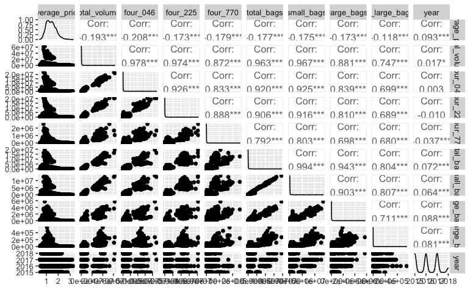

```r
clean_avocado %>%
  select(-c("x1", "region", "is_organic", "month")) %>%
  ggpairs()
```

The correlation with year appears low; however, I do wonder whether this will be different if this is implemented in the model. Aside from this, the remainders remain the same, so I will consider adding: year total_volume total_bags

First build of third part of model

```r
model_3_a <- lm(average_price ~ is_organic + month + year, data = clean_avocado)
model_3_a
```

```
Call:
lm(formula = average_price ~ is_organic + month + year, data = clean_avocado)

Coefficients:
   (Intercept)  is_organicTRUE           month            year
    -107.74016         0.49597         0.02105         0.05395
```

Checking summary stats

```r
summary(model_3_a)
```

```
Call:
lm(formula = average_price ~ is_organic + month + year, data = clean_avocado)

Residuals:
     Min       1Q   Median       3Q      Max
-1.19309 -0.19842 -0.01737  0.18850  1.52350

Coefficients:
                 Estimate Std. Error t value Pr(>|t|)
(Intercept)    -1.077e+02  4.944e+00  -21.79   <2e-16 ***
is_organicTRUE  4.960e-01  4.537e-03  109.33   <2e-16 ***
month           2.105e-02  6.522e-04   32.28   <2e-16 ***
year            5.395e-02  2.452e-03   22.00   <2e-16 ***
---
Signif. codes:  0 ‘***’ 0.001 ‘**’ 0.01 ‘*’ 0.05 ‘.’ 0.1 ‘ ’ 1

Residual standard error: 0.3064 on 18245 degrees of freedom
Multiple R-squared:  0.421, Adjusted R-squared:  0.4209
F-statistic:  4422 on 3 and 18245 DF,  p-value: < 2.2e-16
```

Similarly to month, year had a relatively good impact on the model - it increased from 40.57% to 42.1%, while remaining statistically significant.

Checking the plots

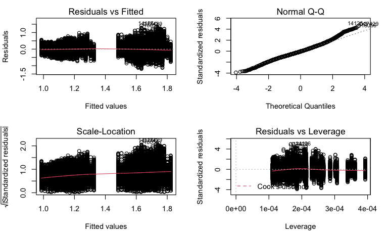

```r
par(mfrow = c(2, 2))
plot(model_3_a)
```

This has improved on the distribution in res v fitted, and has also improved the res v leverage plot. This is a strong contender.

Next I will add total_volume.

```r
model_3_b <- lm(average_price ~ is_organic + month + total_volume, data = clean_avocado)
model_3_b
```

```
Call:
lm(formula = average_price ~ is_organic + month + total_volume,
    data = clean_avocado)

Coefficients:
   (Intercept)  is_organicTRUE           month    total_volume
     1.054e+00       4.869e-01       1.837e-02      -5.623e-09
```

Checking summary stats

```r
summary(model_3_b)
```

```
Call:
lm(formula = average_price ~ is_organic + month + total_volume,
    data = clean_avocado)

Residuals:
     Min       1Q   Median       3Q      Max
-1.15553 -0.20313 -0.02265  0.18878  1.55575

Coefficients:
                 Estimate Std. Error t value Pr(>|t|)
(Intercept)     1.054e+00  5.303e-03 198.736   <2e-16 ***
is_organicTRUE  4.869e-01  4.717e-03 103.227   <2e-16 ***
month           1.837e-02  6.493e-04  28.299   <2e-16 ***
total_volume   -5.623e-09  6.832e-10  -8.231   <2e-16 ***
---
Signif. codes:  0 ‘***’ 0.001 ‘**’ 0.01 ‘*’ 0.05 ‘.’ 0.1 ‘ ’ 1

Residual standard error: 0.3099 on 18245 degrees of freedom
Multiple R-squared:  0.4079,    Adjusted R-squared:  0.4078
F-statistic:  4189 on 3 and 18245 DF,  p-value: < 2.2e-16
```

This only marginally increases the model from 2_c (from 40.5 to 40.7).

Checking the plots

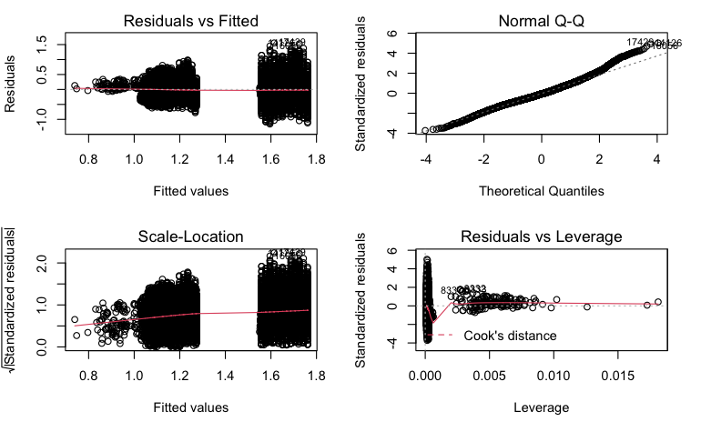

```r
par(mfrow = c(2, 2))
plot(model_3_b)
```

This improves residuals v leverage greatly compared to 3_a, but otherwise does not have the same benefits. This may be an option for a 4th variable.

I will lastly check total_bags

```r
model_3_c <- lm(average_price ~ is_organic + month + total_bags, data = clean_avocado)
model_3_c
```

```
Call:
lm(formula = average_price ~ is_organic + month + total_bags,
    data = clean_avocado)

Coefficients:
   (Intercept)  is_organicTRUE           month      total_bags
     1.052e+00       4.887e-01       1.840e-02      -1.684e-08
```

Checking summary stats

```r
summary(model_3_c)
```

```
Call:
lm(formula = average_price ~ is_organic + month + total_bags,
    data = clean_avocado)

Residuals:
    Min      1Q  Median      3Q     Max
-1.1549 -0.2032 -0.0233  0.1898  1.5557

Coefficients:
                 Estimate Std. Error t value Pr(>|t|)
(Intercept)     1.052e+00  5.293e-03 198.761  < 2e-16 ***
is_organicTRUE  4.887e-01  4.703e-03 103.917  < 2e-16 ***
month           1.840e-02  6.496e-04  28.331  < 2e-16 ***
total_bags     -1.684e-08  2.385e-09  -7.061 1.71e-12 ***
---
Signif. codes:  0 ‘***’ 0.001 ‘**’ 0.01 ‘*’ 0.05 ‘.’ 0.1 ‘ ’ 1

Residual standard error: 0.31 on 18245 degrees of freedom
Multiple R-squared:  0.4073,    Adjusted R-squared:  0.4072
F-statistic:  4179 on 3 and 18245 DF,  p-value: < 2.2e-16
```

This has the same stats as model 3_b

Checking the plots

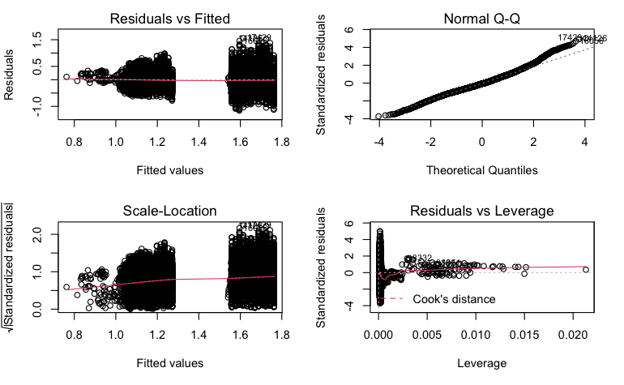

```r
par(mfrow = c(2, 2))
plot(model_3_c)
```

This is also similar to model 3_b.

Before settling on year, I will check the anova.

```r
anova(model_2_c, model_3_a)
```

```
Analysis of Variance Table

Model 1: average_price ~ is_organic + month
Model 2: average_price ~ is_organic + month + year
  Res.Df    RSS Df Sum of Sq      F    Pr(>F)
1  18246 1758.6
2  18245 1713.1  1    45.451 484.05 < 2.2e-16 ***
---
Signif. codes:  0 ‘***’ 0.001 ‘**’ 0.01 ‘*’ 0.05 ‘.’ 0.1 ‘ ’ 1
```

As I now have 3 variables in my model, I need to be cautious of overfitting, so I will begin to watch the adjusted r2 values relative to the r2 values.

I feel confident in saying that the options I can explore are: total_volume four_046

First build of fourth part of model

```r
model_4_a <- lm(average_price ~ is_organic + month + year + total_volume, data = clean_avocado)
model_4_a
```

```
Call:
lm(formula = average_price ~ is_organic + month + year + total_volume,
    data = clean_avocado)

Coefficients:
   (Intercept)  is_organicTRUE           month            year    total_volume
    -1.083e+02       4.866e-01       2.092e-02       5.423e-02      -5.824e-09
```

Checking summary stats

```r
summary(model_4_a)
```

```
Call:
lm(formula = average_price ~ is_organic + month + year + total_volume,
    data = clean_avocado)

Residuals:
     Min       1Q   Median       3Q      Max
-1.19364 -0.19828 -0.01635  0.18632  1.52385

Coefficients:
                 Estimate Std. Error t value Pr(>|t|)
(Intercept)    -1.083e+02  4.935e+00 -21.946   <2e-16 ***
is_organicTRUE  4.866e-01  4.655e-03 104.536   <2e-16 ***
month           2.092e-02  6.510e-04  32.140   <2e-16 ***
year            5.423e-02  2.447e-03  22.159   <2e-16 ***
total_volume   -5.824e-09  6.742e-10  -8.637   <2e-16 ***
---
Signif. codes:  0 ‘***’ 0.001 ‘**’ 0.01 ‘*’ 0.05 ‘.’ 0.1 ‘ ’ 1

Residual standard error: 0.3058 on 18244 degrees of freedom
Multiple R-squared:  0.4234,    Adjusted R-squared:  0.4233
F-statistic:  3349 on 4 and 18244 DF,  p-value: < 2.2e-16
```

There is again only 0.2 improvement (42.34 from 42.1).

Checking plots

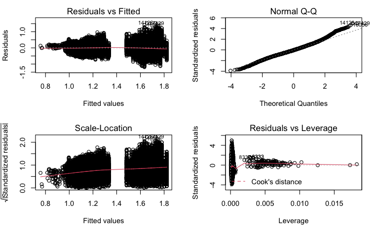

```r
par(mfrow = c(2, 2))
plot(model_4_a)
```

This is similar to the previous one with total_volume, improvement in res v leverage.

I will now check four_046

```r
model_4_b <- lm(average_price ~ is_organic + month + year + four_046, data = clean_avocado)
model_4_b
```

```
Call:
lm(formula = average_price ~ is_organic + month + year + four_046,
    data = clean_avocado)

Coefficients:
   (Intercept)  is_organicTRUE           month            year        four_046
    -1.077e+02       4.835e-01       2.085e-02       5.391e-02      -2.178e-08
```

Summary stats

```r
summary(model_4_b)
```

```
Call:
lm(formula = average_price ~ is_organic + month + year + four_046,
    data = clean_avocado)

Residuals:
     Min       1Q   Median       3Q      Max
-1.19386 -0.19803 -0.01692  0.18751  1.52416

Coefficients:
                 Estimate Std. Error t value Pr(>|t|)
(Intercept)    -1.077e+02  4.926e+00  -21.86   <2e-16 ***
is_organicTRUE  4.835e-01  4.639e-03  104.23   <2e-16 ***
month           2.085e-02  6.499e-04   32.08   <2e-16 ***
year            5.391e-02  2.443e-03   22.07   <2e-16 ***
four_046       -2.178e-08  1.834e-09  -11.88   <2e-16 ***
---
Signif. codes:  0 ‘***’ 0.001 ‘**’ 0.01 ‘*’ 0.05 ‘.’ 0.1 ‘ ’ 1

Residual standard error: 0.3053 on 18244 degrees of freedom
Multiple R-squared:  0.4255,    Adjusted R-squared:  0.4253
F-statistic:  3378 on 4 and 18244 DF,  p-value: < 2.2e-16
```

For comprehension, I will check the plots.

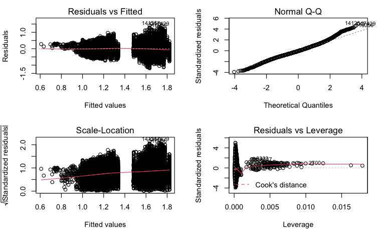

```r
par(mfrow = c(2, 2))
plot(model_4_b)
```

These plots are still not as strong as they were in model 3_a. Now there is a split in two groups, and the funnel in res v fitted has returned.

There is one final option to consider to add to this model which are regions, which I will attempt - although there are many, and the model may struggle with these, I will explore this for the sake of completeness.

```r
model_4_c <- lm(average_price ~ is_organic + month + year + region, data = clean_avocado)
model_4_c
```

```
Call:
lm(formula = average_price ~ is_organic + month + year + region,
    data = clean_avocado)

Coefficients:
              (Intercept)             is_organicTRUE                      month                       year              regionAtlanta  regionBaltimoreWashington
               -1.076e+02                  4.959e-01                  2.105e-02                  5.394e-02                 -2.231e-01                 -2.680e-02
              regionBoise               regionBoston     regionBuffaloRochester           regionCalifornia            regionCharlotte              regionChicago
               -2.129e-01                 -3.015e-02                 -4.420e-02                 -1.657e-01                  4.500e-02                 -4.260e-03
   regionCincinnatiDayton             regionColumbus        regionDallasFtWorth               regionDenver              regionDetroit          regionGrandRapids
               -3.518e-01                 -3.083e-01                 -4.754e-01                 -3.425e-01                 -2.849e-01                 -5.604e-02
         regionGreatLakes   regionHarrisburgScranton  regionHartfordSpringfield              regionHouston         regionIndianapolis         regionJacksonville
               -2.225e-01                 -4.775e-02                  2.576e-01                 -5.131e-01                 -2.470e-01                 -5.009e-02
           regionLasVegas           regionLosAngeles           regionLouisville    regionMiamiFtLauderdale             regionMidsouth            regionNashville
               -1.801e-01                 -3.450e-01                 -2.743e-01                 -1.325e-01                 -1.563e-01                 -3.489e-01
   regionNewOrleansMobile              regionNewYork            regionNortheast   regionNorthernNewEngland              regionOrlando         regionPhiladelphia
               -2.562e-01                  1.665e-01                  4.089e-02                 -8.364e-02                 -5.482e-02                  7.109e-02
      regionPhoenixTucson           regionPittsburgh               regionPlains             regionPortland    regionRaleighGreensboro      regionRichmondNorfolk
               -3.366e-01                 -1.967e-01                 -1.245e-01                 -2.433e-01                 -5.917e-03                 -2.697e-01
            regionRoanoke           regionSacramento             regionSanDiego         regionSanFrancisco              regionSeattle        regionSouthCarolina
               -3.131e-01                  6.053e-02                 -1.629e-01                  2.432e-01                 -1.185e-01                 -1.578e-01
       regionSouthCentral            regionSoutheast              regionSpokane              regionStLouis             regionSyracuse                regionTampa
               -4.598e-01                 -1.630e-01                 -1.154e-01                 -1.304e-01                 -4.071e-02                 -1.522e-01
            regionTotalUS                 regionWest     regionWestTexNewMexico
               -2.420e-01                 -2.888e-01                 -2.967e-01
```

Summary stats

```r
summary(model_4_c)
```

```
Call:
lm(formula = average_price ~ is_organic + month + year + region,
    data = clean_avocado)

Residuals:
     Min       1Q   Median       3Q      Max
-1.04478 -0.15910 -0.00461  0.14914  1.51306

Coefficients:
                            Estimate Std. Error t value Pr(>|t|)
(Intercept)               -1.076e+02  4.172e+00 -25.786  < 2e-16 ***
is_organicTRUE             4.959e-01  3.828e-03 129.567  < 2e-16 ***
month                      2.105e-02  5.502e-04  38.252  < 2e-16 ***
year                       5.394e-02  2.069e-03  26.073  < 2e-16 ***
regionAtlanta             -2.231e-01  1.989e-02 -11.217  < 2e-16 ***
regionBaltimoreWashington -2.680e-02  1.989e-02  -1.348 0.177723
regionBoise               -2.129e-01  1.989e-02 -10.705  < 2e-16 ***
regionBoston              -3.015e-02  1.989e-02  -1.516 0.129546
regionBuffaloRochester    -4.420e-02  1.989e-02  -2.223 0.026254 *
regionCalifornia          -1.657e-01  1.989e-02  -8.333  < 2e-16 ***
regionCharlotte            4.500e-02  1.989e-02   2.263 0.023661 *
regionChicago             -4.260e-03  1.989e-02  -0.214 0.830372
regionCincinnatiDayton    -3.518e-01  1.989e-02 -17.692  < 2e-16 ***
regionColumbus            -3.083e-01  1.989e-02 -15.500  < 2e-16 ***
regionDallasFtWorth       -4.754e-01  1.989e-02 -23.907  < 2e-16 ***
regionDenver              -3.425e-01  1.989e-02 -17.220  < 2e-16 ***
regionDetroit             -2.849e-01  1.989e-02 -14.328  < 2e-16 ***
regionGrandRapids         -5.604e-02  1.989e-02  -2.818 0.004842 **
regionGreatLakes          -2.225e-01  1.989e-02 -11.187  < 2e-16 ***
regionHarrisburgScranton  -4.775e-02  1.989e-02  -2.401 0.016354 *
regionHartfordSpringfield  2.576e-01  1.989e-02  12.953  < 2e-16 ***
regionHouston             -5.131e-01  1.989e-02 -25.801  < 2e-16 ***
regionIndianapolis        -2.470e-01  1.989e-02 -12.422  < 2e-16 ***
regionJacksonville        -5.009e-02  1.989e-02  -2.519 0.011788 *
regionLasVegas            -1.801e-01  1.989e-02  -9.057  < 2e-16 ***
regionLosAngeles          -3.450e-01  1.989e-02 -17.350  < 2e-16 ***
regionLouisville          -2.743e-01  1.989e-02 -13.795  < 2e-16 ***
regionMiamiFtLauderdale   -1.325e-01  1.989e-02  -6.665 2.72e-11 ***
regionMidsouth            -1.563e-01  1.989e-02  -7.858 4.12e-15 ***
regionNashville           -3.489e-01  1.989e-02 -17.546  < 2e-16 ***
```

[output cut: 18 more lines]

```
regionSouthCentral        -4.598e-01  1.989e-02 -23.120  < 2e-16 ***
regionSoutheast           -1.630e-01  1.989e-02  -8.197 2.62e-16 ***
regionSpokane             -1.154e-01  1.989e-02  -5.805 6.54e-09 ***
regionStLouis             -1.304e-01  1.989e-02  -6.558 5.61e-11 ***
regionSyracuse            -4.071e-02  1.989e-02  -2.047 0.040666 *
regionTampa               -1.522e-01  1.989e-02  -7.653 2.07e-14 ***
regionTotalUS             -2.420e-01  1.989e-02 -12.169  < 2e-16 ***
regionWest                -2.888e-01  1.989e-02 -14.523  < 2e-16 ***
regionWestTexNewMexico    -2.967e-01  1.993e-02 -14.885  < 2e-16 ***
---
Signif. codes:  0 ‘***’ 0.001 ‘**’ 0.01 ‘*’ 0.05 ‘.’ 0.1 ‘ ’ 1

Residual standard error: 0.2585 on 18192 degrees of freedom
Multiple R-squared:  0.5891,    Adjusted R-squared:  0.5878
F-statistic: 465.7 on 56 and 18192 DF,  p-value: < 2.2e-16
```

This improves the model’s r-squared rating, quite significantly, to 58.91. Additionally, many of the regions are statistically significant, some not - to check if they are overall, as a group, I will compare to 3_a using anova.

```r
anova(model_3_a, model_4_c)
```

```
Analysis of Variance Table

Model 1: average_price ~ is_organic + month + year
Model 2: average_price ~ is_organic + month + year + region
  Res.Df    RSS Df Sum of Sq      F    Pr(>F)
1  18245 1713.1
2  18192 1215.9 53    497.22 140.36 < 2.2e-16 ***
---
Signif. codes:  0 ‘***’ 0.001 ‘**’ 0.01 ‘*’ 0.05 ‘.’ 0.1 ‘ ’ 1
```

This confirms that model_4_c is statistically significant compared to model 3_a.

As a final check, I will explore the plots.

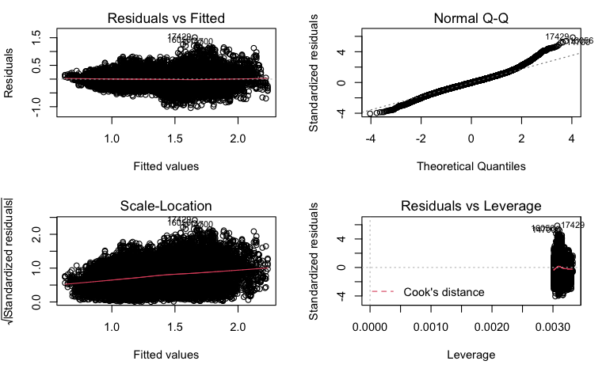

This is an excellent distribution across res v fitted, and the same for scale v location. There is some tail off on the QQ plot, but on the whole, it fits the normal distribution. The model doesn’t seem to fit the res v leverage plot great, but the other plots are strong enough to counter-balance, from my perspective.

Therefore, my final explanatory model, is:

lm(formula = average_price ~ is_organic + month + year + region, data = clean_avocado)